# Monte Carlo Methods in Psychophysics

# A more sophisticated model

Let’s go a step further in our modelling and assume that: - the observer is engaging in a blob detection task - the observer is linear

I’m going to use the “imager” package for image processing

# The task

The target is a blob:

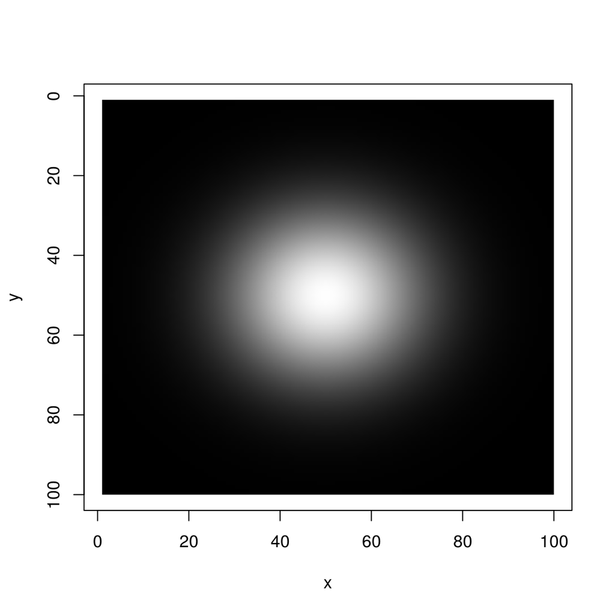

```r
library(imager)
blob <- as.cimg(function(x,y) dnorm(x,m=50,sd=15)*dnorm(y,m=50,sd=15),100,100)
plot(blob)
```

# The model, in words

The observer tries to match the actual stimulus to its internal representation of the target. In addition, there is some noise. Then the observer compares the result to a threshold and answers accordingly. Also, everything is linear and the noise is Gaussian.

# The model, in equations

The observer is linear, ie. the internal decision variable is: $z_i = \int w(s)x(s) ds + \epsilon$ where $s$ indexes space, $x(s)$ is the stimulus and $\epsilon$ is a noise term. $w(s)$ is a spatial weighting term and represents the observer’s internal representation of the target (the *template*)

# Example

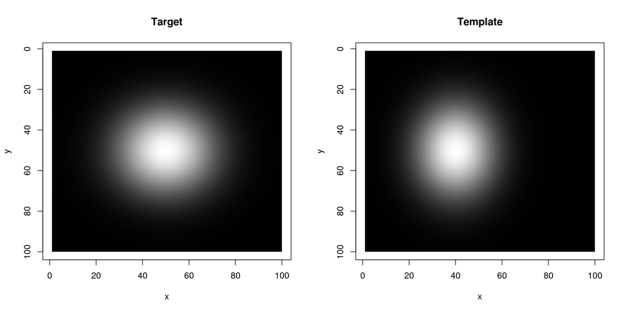

```r
template <- as.cimg(function(x,y) dnorm(x,m=40,sd=12)*dnorm(y,m=50,sd=16),100,100)
layout(t(1:2))
plot(blob,main="Target");plot(template,main="Template")
```

# Simulating responses

Here’s a full implementation of the model

```r
blob <- blob/sqrt(sum(blob^2)) #Normalise to unit energy
template <- template/sqrt(sum(template^2))
do.trial <- function(x,template,beta)
    {
        z <- sum(x*template) - beta +rnorm(1)
        sign(z)
    }
```

# FA and H rates

```r
y.sig <- replicate(100,do.trial(blob,template,.1))
mean(y.sig == 1)
```

```
## [1] 0.83
```

```r
y.noi <- replicate(100,do.trial(0*blob,template,.1))
mean(y.noi == 1)
```

```
## [1] 0.46
```

# Adding stimulus uncertainty

Classical detection models often assume stimulus uncertainty (the observer isn’t always sure where the target is going to appear). It’s now easy to add that feature to our model by assuming that the template undergoes random shifts.

# Random shifts

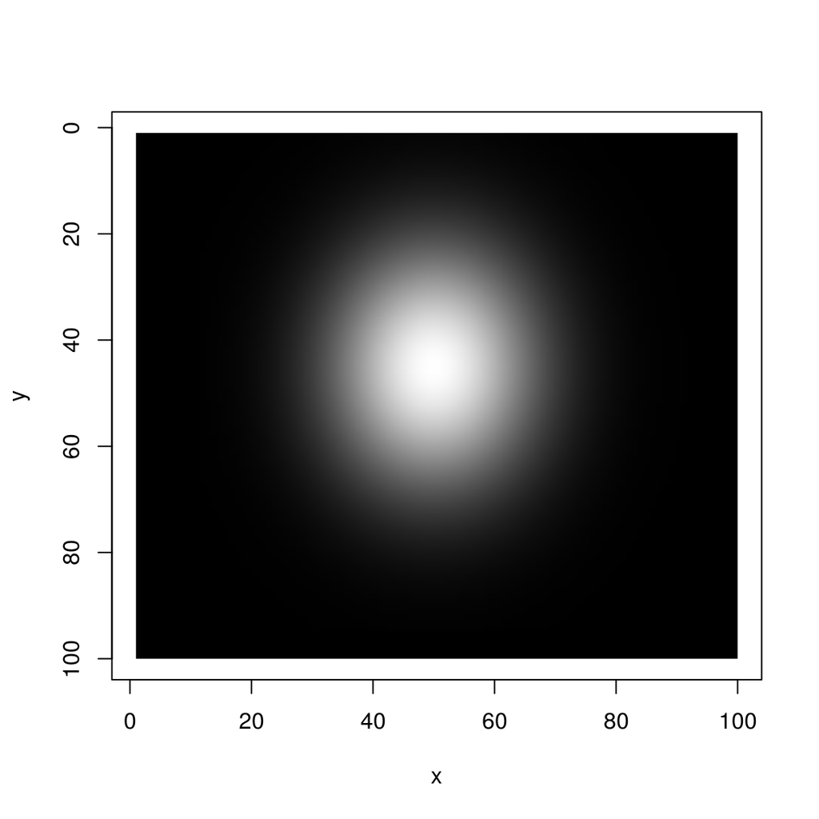

```r
imshift(template,10,-5) %>% plot #Shift by 10 pixels in x, -5 in y
```

# Adding stimulus uncertainty

```r
do.trial <- function(x,template,beta,shift.sd)
    {
        shift <- rnorm(2,sd=shift.sd)
        template <- imshift(template,shift[1],shift[2])
        z <- sum(x*template) - beta +rnorm(1)
        sign(z)
    }
```

# And finally

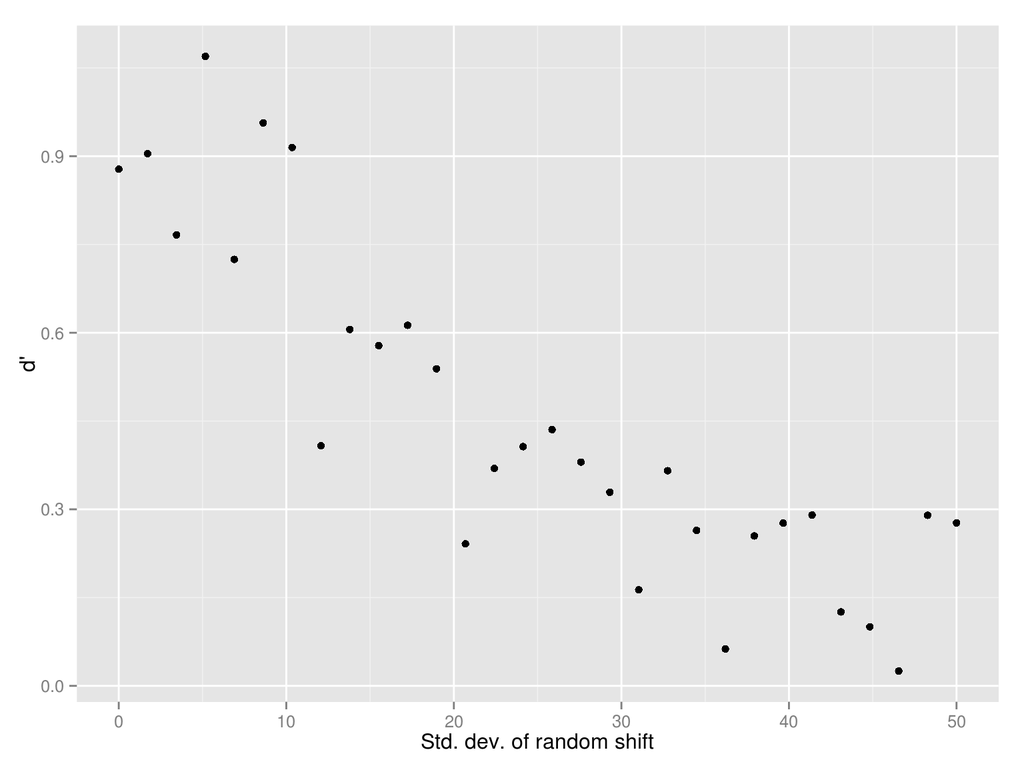

```r
dprime.shift <- function(shift.sd,n=200) {
y.noi <- replicate(n,do.trial(0,template,.1,shift.sd=shift.sd))
y.sig <- replicate(n,do.trial(blob,template,.1,shift.sd=shift.sd))
c(dp=dprime(mean(y.noi==1),mean(y.sig==1)),shift.sd=shift.sd)
}
shifts <- seq(0,50,l=30)
dat <- ldply(shifts,dprime.shift)
p <- ggplot(dat,aes(shift.sd,dp))+geom_point()+labs(x="Std. dev. of random shift",y="d'")
print(p)
```

# Conclusion

- Given the right tools, simulating data using observer models is easy
- Just write a computer program and insert random variables where needed
- I suggest using R, Python is also very good, Matlab not so much
- General strategy: start small (here SDT), and add components one-by-one
- It really really helps build statistical understanding

# Caveats

- Simulation good, analytical understanding better:
- Few things are more annoying than modelling papers that describe computer programs using horrible notation
- Analytical results are often more general
- Ideally, have both

# Going further

- Good topics to know about:
- Methods for generating random variables
- Parametric bootstrap
- Approximate Bayesian Computation
- Monte Carlo methods: D.P. Kroese, T. Taimre, Z.I. Botev (2011). Handbook of Monte Carlo Methods, Wiley Series in Probability and Statistics, John Wiley and Sons, New York.